# Report of Previous Study

## Description Table

Table 1 Distribution of epidemiology and clinical data of all mpox cases between 2023-2024

|  | Total (N=87) | WGS (N=53) | Non-WGS (N=34) |
| --- | --- | --- | --- |
| Sex |  |  |  |
| Male | 83 (95.4%) | 50 (94.3%) | 33 (97.1%) |
| Female | 4 (4.6%) | 3 (5.7%) | 1 (2.9%) |
| Age Group |  |  |  |
| 20-64 | 86 (98.9%) | 53 (100%) | 33 (97.1%) |
| 13-19 | 1 (1.1%) | 0 (0%) | 1 (2.9%) |
| Sex Orientation |  |  |  |
| MSM | 52 (59.8%) | 34 (64.2%) | 18 (52.9%) |
| Bisexual | 22 (25.3%) | 11 (20.8%) | 11 (32.4%) |
| Heterosexual | 13 (14.9%) | 8 (15.1%) | 5 (14.7%) |
| Travel History |  |  |  |
| No | 79 (90.8%) | 47 (88.7%) | 32 (94.1%) |
| Local | 3 (3.4%) | 2 (3.8%) | 1 (2.9%) |
| East Asia | 2 (2.3%) | 1 (1.9%) | 1 (2.9%) |
| Southeast Asia | 2 (2.3%) | 2 (3.8%) | 0 (0%) |
| Mediterranean | 1 (1.1%) | 1 (1.9%) | 0 (0%) |
| Origin Report |  |  |  |
| PHC | 59 (67.8%) | 38 (71.7%) | 21 (61.8%) |
| Hospital | 28 (32.2%) | 15 (28.3%) | 13 (38.2%) |
| Location |  |  |  |
| The Greater Jakarta | 77 (88.5%) | 50 (94.3%) | 27 (79.4%) |
| Bandung | 2 (2.3%) | 2 (3.8%) | 0 (0%) |
| Cirebon | 2 (2.3%) | 1 (1.9%) | 1 (2.9%) |
| Sleman | 2 (2.3%) | 0 (0%) | 2 (5.9%) |
| Batam | 1 (1.1%) | 0 (0%) | 1 (2.9%) |
| Madiun | 1 (1.1%) | 0 (0%) | 1 (2.9%) |
| Surabaya | 1 (1.1%) | 0 (0%) | 1 (2.9%) |
| Yogyakarta | 1 (1.1%) | 0 (0%) | 1 (2.9%) |
| Severity Criteria |  |  |  |
| Mild | 45 (51.7%) | 29 (54.7%) | 16 (47.1%) |
| Severe | 39 (44.8%) | 23 (43.4%) | 16 (47.1%) |
| Asymptomatic | 3 (3.4%) | 1 (1.9%) | 2 (5.9%) |
| Clade |  |  |  |
| IIb (C.1) | 42 (48.3%) | 42 (79.2%) | 0 (0%) |
| IIb (B.1.3) | 9 (10.3%) | 9 (17.0%) | 0 (0%) |
| IIb (A.1.1) | 1 (1.1%) | 1 (1.9%) | 0 (0%) |
| IIb (B.1) | 1 (1.1%) | 1 (1.9%) | 0 (0%) |
| Non-Detected | 34 (39.1%) | 0 (0%) | 34 (100%) |
| HIV Status |  |  |  |
| Yes | 62 (71.3%) | 41 (77.4%) | 21 (61.8%) |
| No | 25 (28.7%) | 12 (22.6%) | 13 (38.2%) |
| Isolation Status |  |  |  |
| Self Isolation | 66 (75.9%) | 40 (75.5%) | 26 (76.5%) |
| Hospital Isolation | 21 (24.1%) | 13 (24.5%) | 8 (23.5%) |
| Length of Treatment (days) |  |  |  |
| Mean (SD) | 30.1 (15.8) | 31.0 (15.4) | 28.7 (16.5) |
| Median [Min, Max] | 27.0 [10.0, 109] | 27.0 [10.0, 109] | 24.0 [14.0, 103] |
| Final Status |  |  |  |
| Recovered | 87 (100%) | 53 (100%) | 34 (100%) |

## Description Table by Clade

Table 2 Descriptive summary of the relationships between different Clades (IIb sub-clade or lineages) and clinical conditions,

|  | Total (N=53) | IIb (C.1) (N=42) | IIb (B.1.3) (N=9) | IIb (A.1.1) (N=1) | IIb (B.1) (N=1) |
| --- | --- | --- | --- | --- | --- |
| Severity |  |  |  |  |  |
| Mild | 29 (54.7%) | 25 (59.5%) | 3 (33.3%) | 1 (100%) | 0 (0%) |
| Severe | 23 (43.4%) | 16 (38.1%) | 6 (66.7%) | 0 (0%) | 1 (100%) |
| Asymptomatic | 1 (1.9%) | 1 (2.4%) | 0 (0%) | 0 (0%) | 0 (0%) |
| Length of Treatment |  |  |  |  |  |
| ≤ 14 days | 1 (1.9%) | 1 (2.4%) | 0 (0%) | 0 (0%) | 0 (0%) |
| ≥ 14 days | 52 (98.1%) | 41 (97.6%) | 9 (100%) | 1 (100%) | 1 (100%) |
| HIV |  |  |  |  |  |
| No | 12 (22.6%) | 10 (23.8%) | 2 (22.2%) | 0 (0%) | 0 (0%) |
| Yes | 41 (77.4%) | 32 (76.2%) | 7 (77.8%) | 1 (100%) | 1 (100%) |
| ART_treatment |  |  |  |  |  |
| Non ART | 7 (13.2%) | 4 (9.5%) | 2 (22.2%) | 0 (0%) | 1 (100%) |
| ART | 33 (62.3%) | 27 (64.3%) | 5 (55.6%) | 1 (100%) | 0 (0%) |
| Treatment Interruption | 1 (1.9%) | 1 (2.4%) | 0 (0%) | 0 (0%) | 0 (0%) |
| Non HIV | 12 (22.6%) | 10 (23.8%) | 2 (22.2%) | 0 (0%) | 0 (0%) |

## Epidemic Curve

Figure 1 The figure A. shows the epi-curve of mpox cases monthly in Indonesia, the cases were grouped into non-WGS and WGS samples. Meanwhile, the B. illustrates the trend of sub-clade among the WGS cases

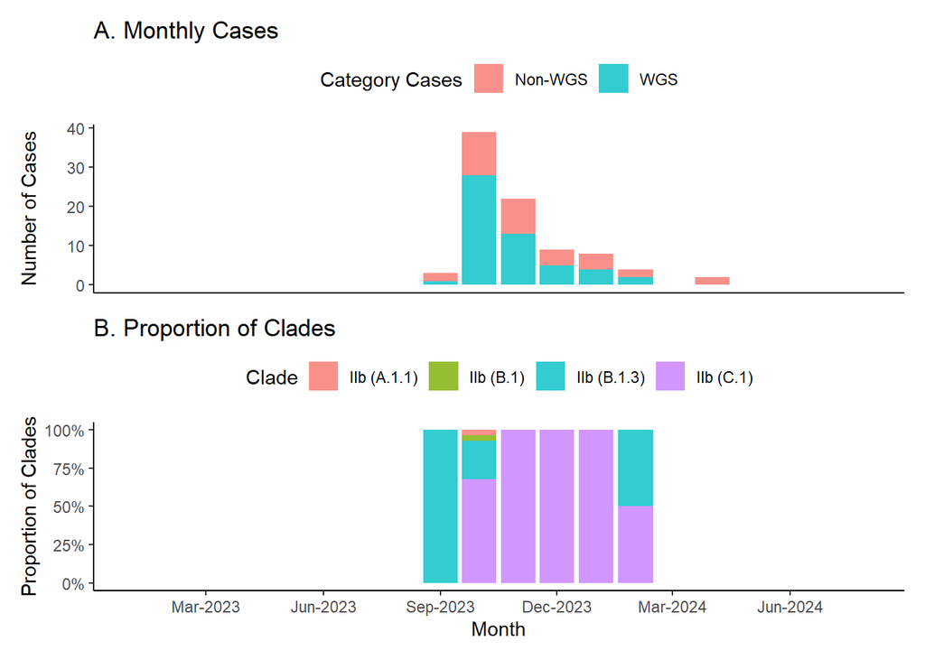